# pat_eda

Patrick McHugh

3/30/2022

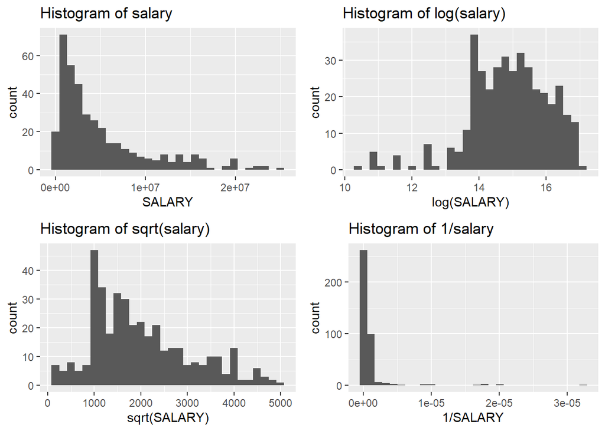

```r
player_data <- read.csv("data/PlayerData.csv", row.names = 1)

y_hist = player_data %>%
    ggplot(aes(x = SALARY)) + geom_histogram() + ggtitle("Histogram of salary")
logy_hist = player_data %>%
    ggplot(aes(x = log(SALARY))) + geom_histogram() + ggtitle("Histogram of log(salary)")
sqrty_hist = player_data %>%
    ggplot(aes(x = sqrt(SALARY))) + geom_histogram() + ggtitle("Histogram of sqrt(salary)")
invy_hist = player_data %>%
    ggplot(aes(x = 1/SALARY)) + geom_histogram() + ggtitle("Histogram of 1/salary")
grid.arrange(y_hist, logy_hist, sqrty_hist, invy_hist, nrow = 2, ncol = 2)
```

We can see that the distribution of salary is heavily skewed to the right. We expect to transform this variable to perform linear regression. After attempting several transformations such as an inverse and square root, a log transformation seems most appropriate, althought not perfect. We will consider other transformations and the Box-Cox method during the analysis.

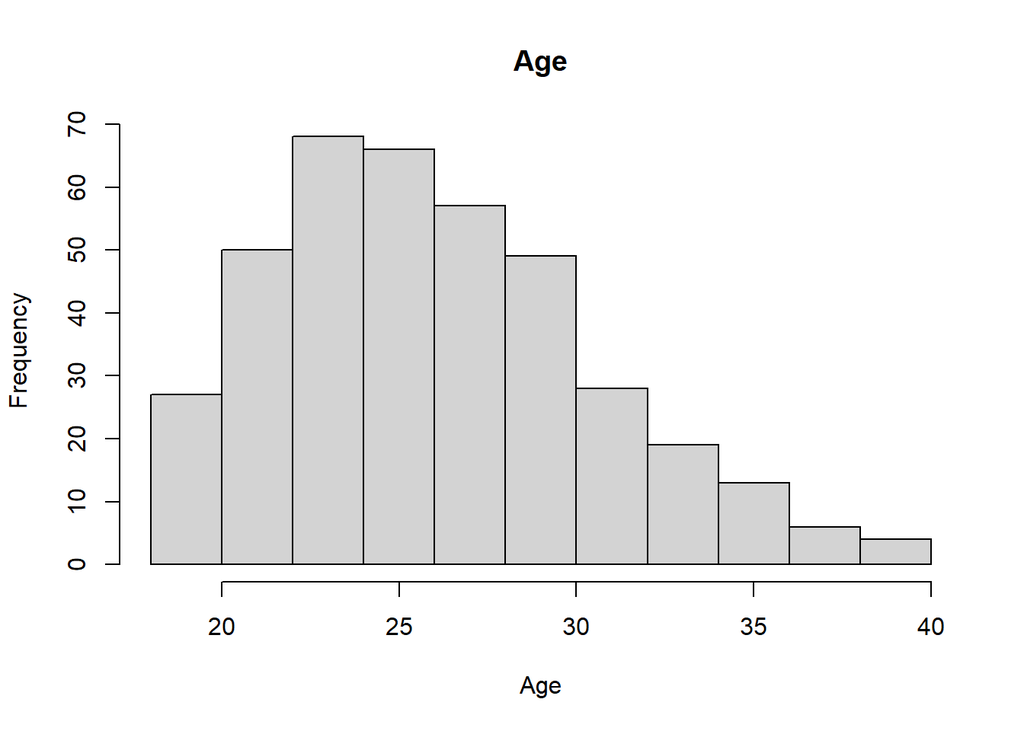

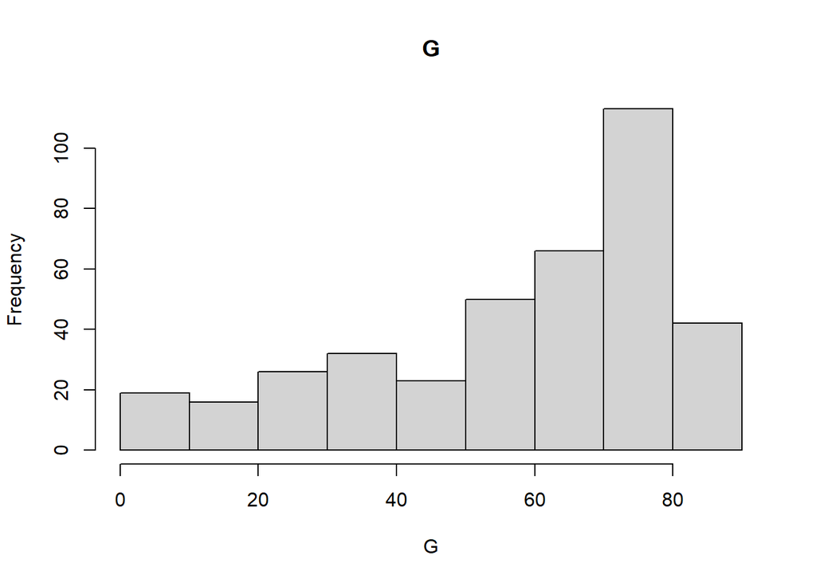

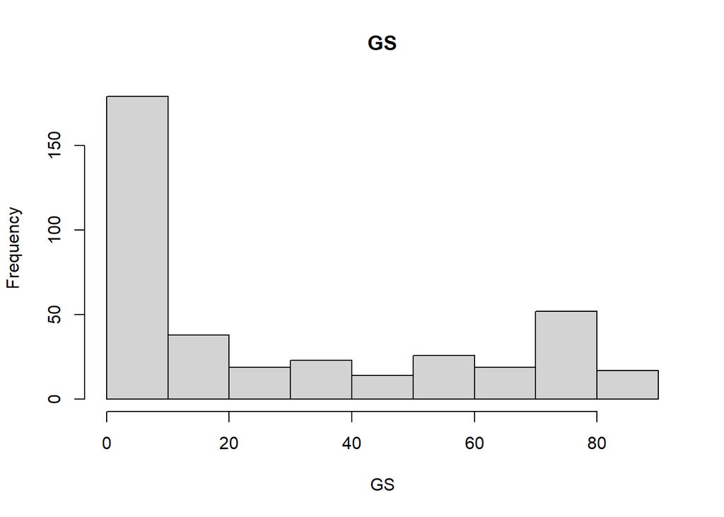

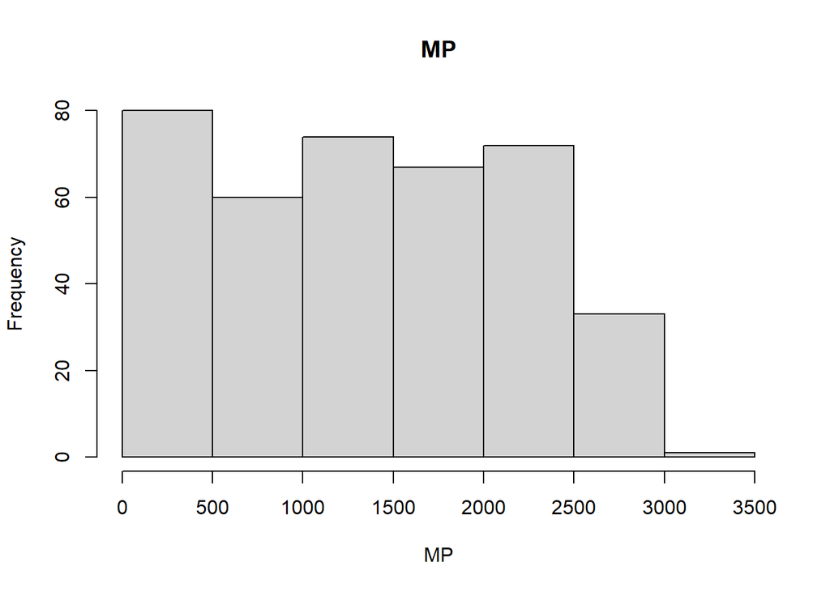

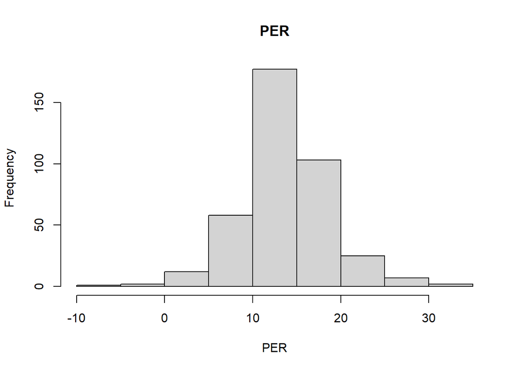

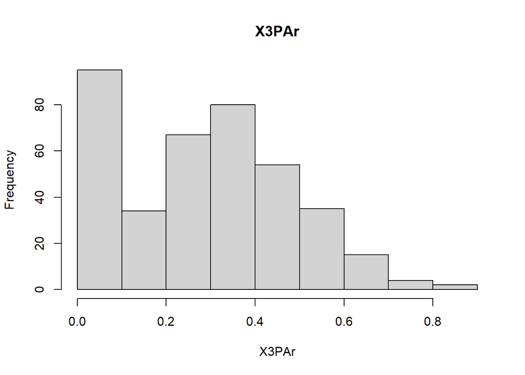

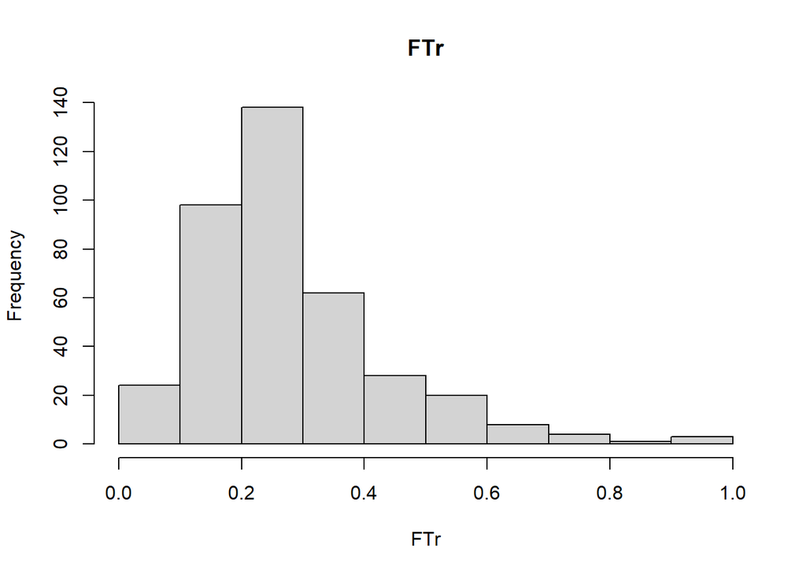

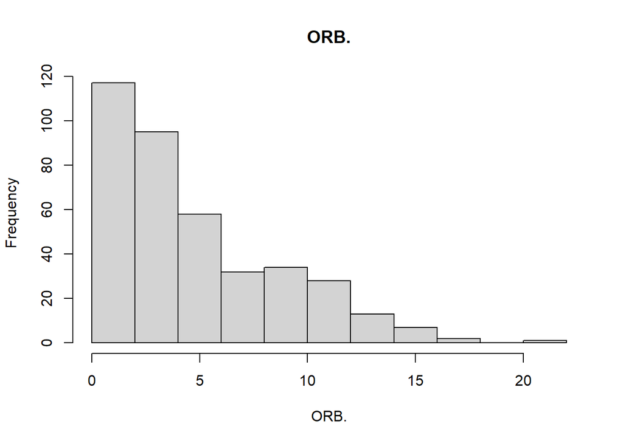

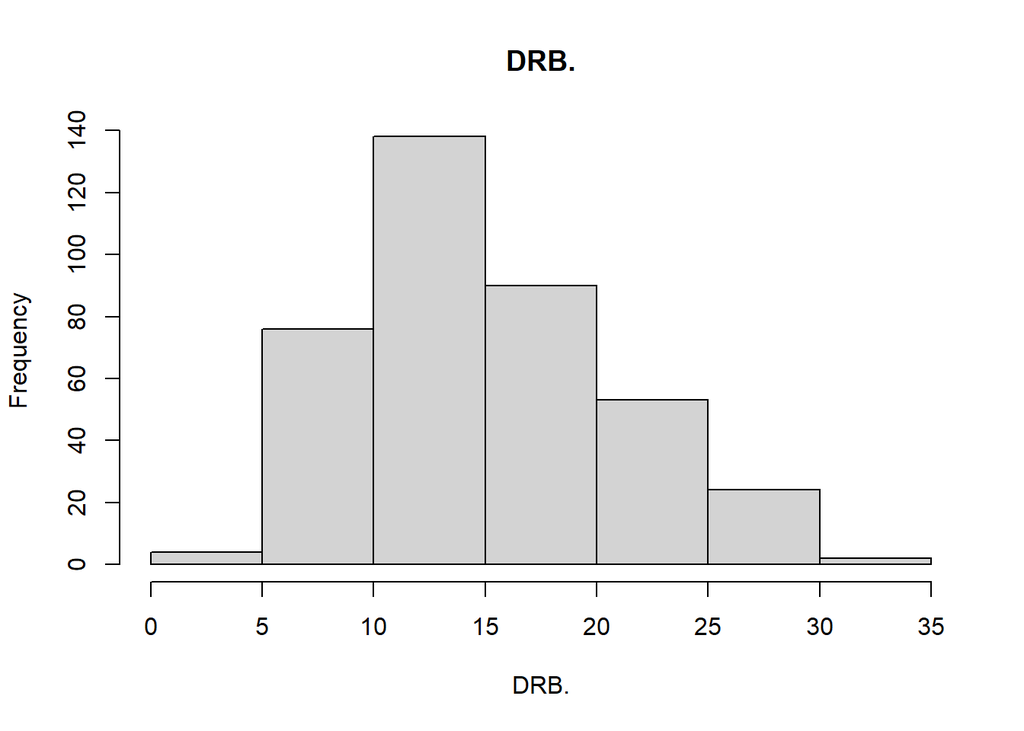

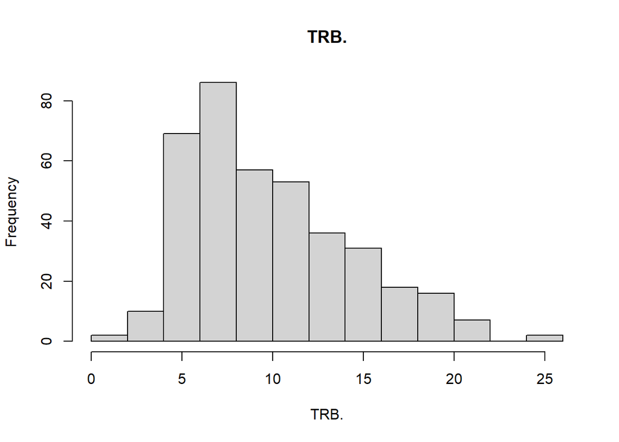

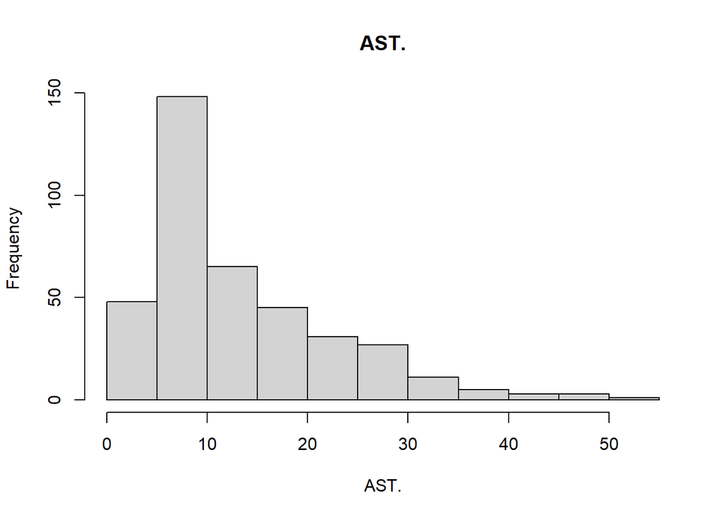

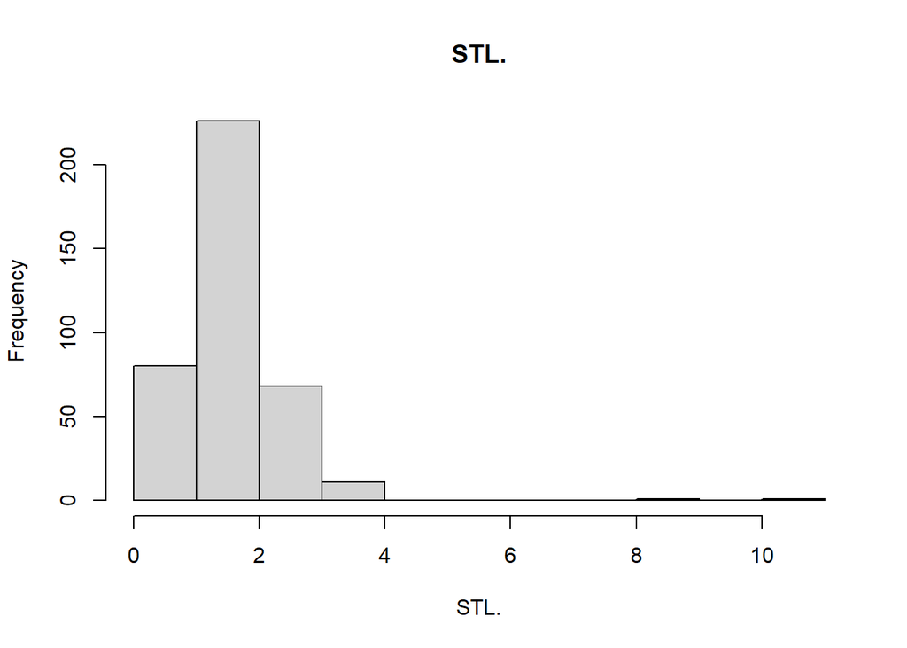

[15 more figures not shown]

```r
numeric_cols = c("Age", "G", "GS", "MP", "PER", "X3PAr", "FTr", "ORB.",
    "DRB.", "TRB.", "AST.", "STL.", "BLK.", "TOV.", "USG.", "ORtg", "DRtg",
    "OWS", "DWS", "WS", "WS.48", "OBPM", "DBPM", "BPM", "VORP", "PTS",
    "TS.")
categorical_cols = c("Tm", "Pos", "International")
for (column in numeric_cols) {
    # c = sym(column) h = player_data %>% ggplot(aes(x = c)) +
    # geom_histogram() + ggtitle(paste('Histogram of', column))
    hist(player_data[, column], xlab = column, main = column)
}
```

When looking at the covariates, many appear to be normally distributed and satisfy the assumptions used by the linear model. Some have a right skew, including many counting stats such as rebounds, blocks, and points. Games started is fairly uniformly distributed from 10-70, with a higher density from 0-10 and 70-82. Games played has a left skew. We will experiment with log, inverse, square root, and squaring transformations. We would prefer approximately normal distributions of the covariates, to help obtain normally distributed residuals, and to avoid high leverage cases affecting the mean function.

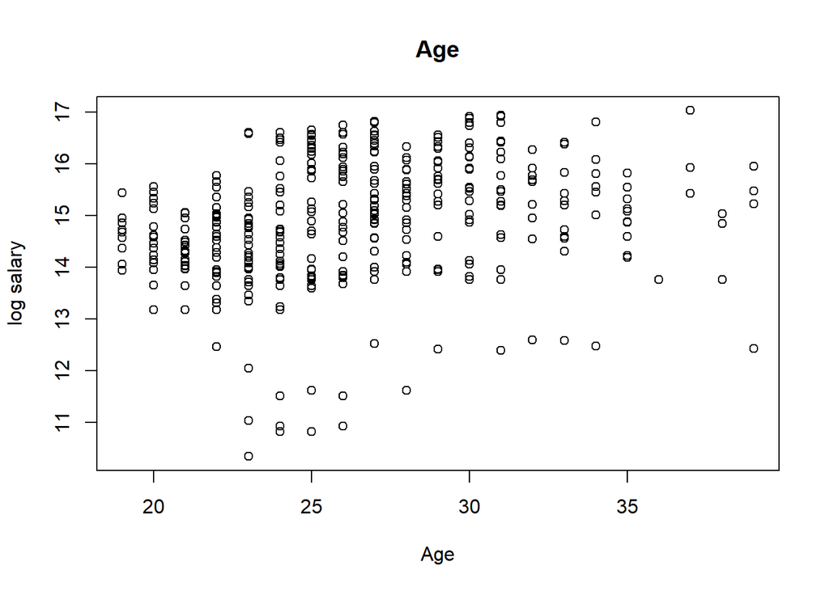

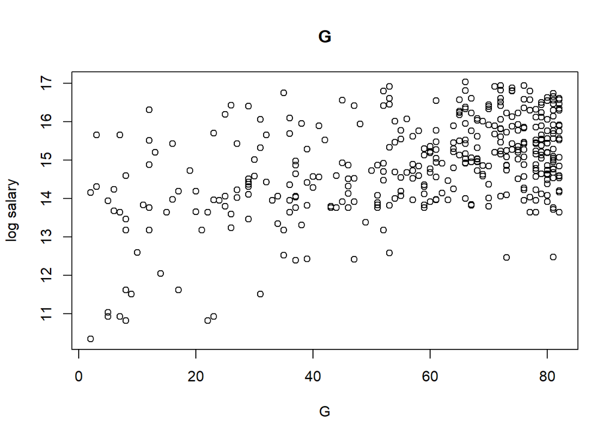

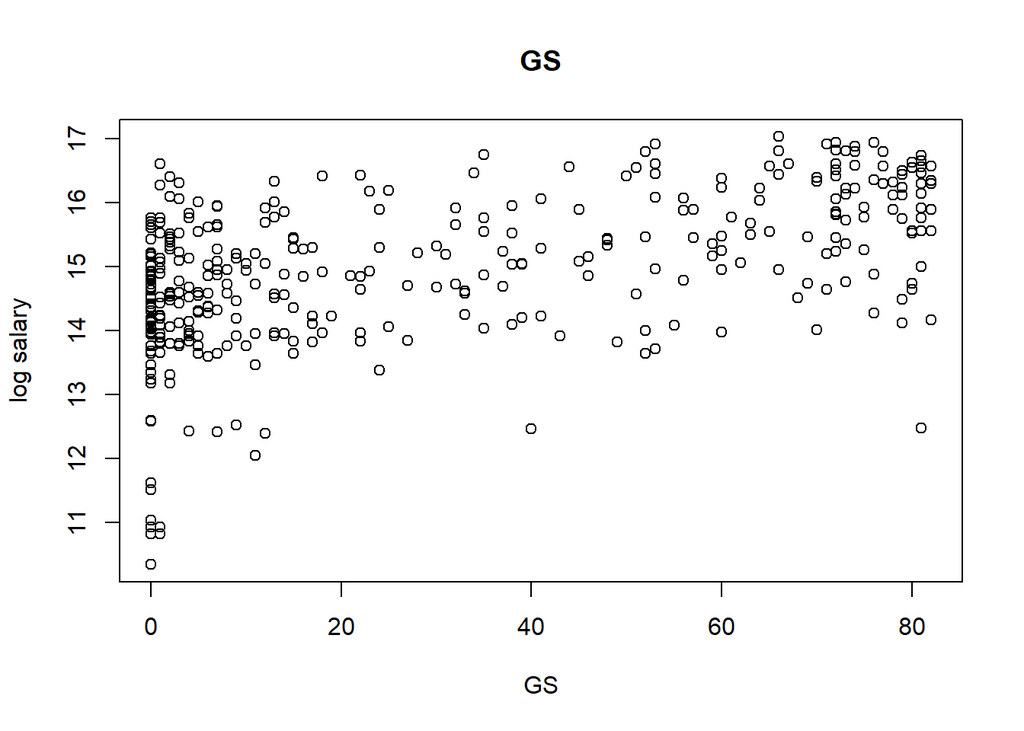

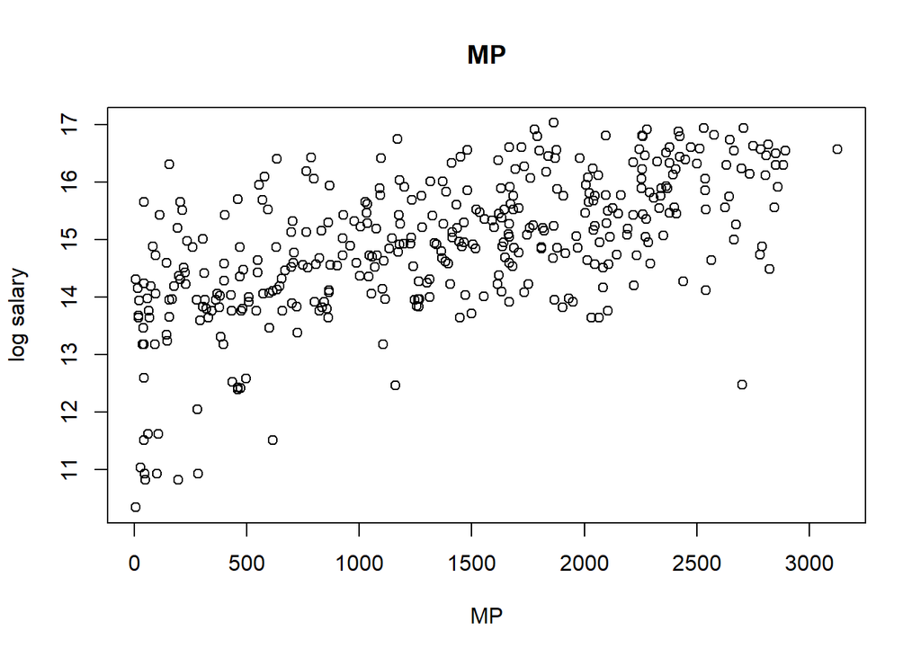

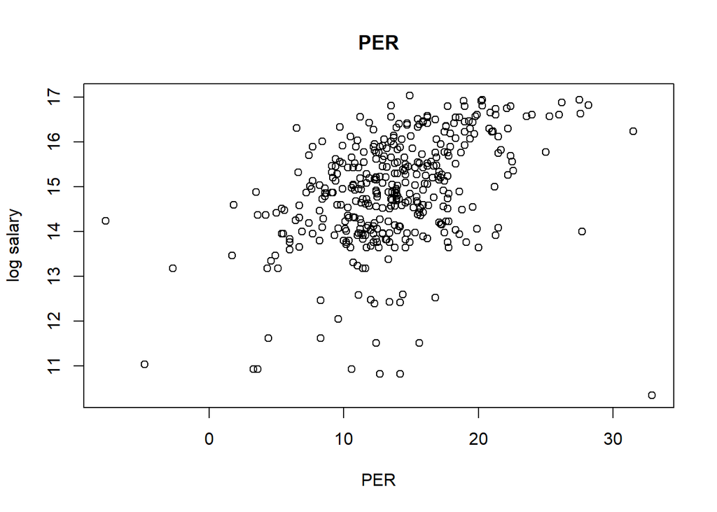

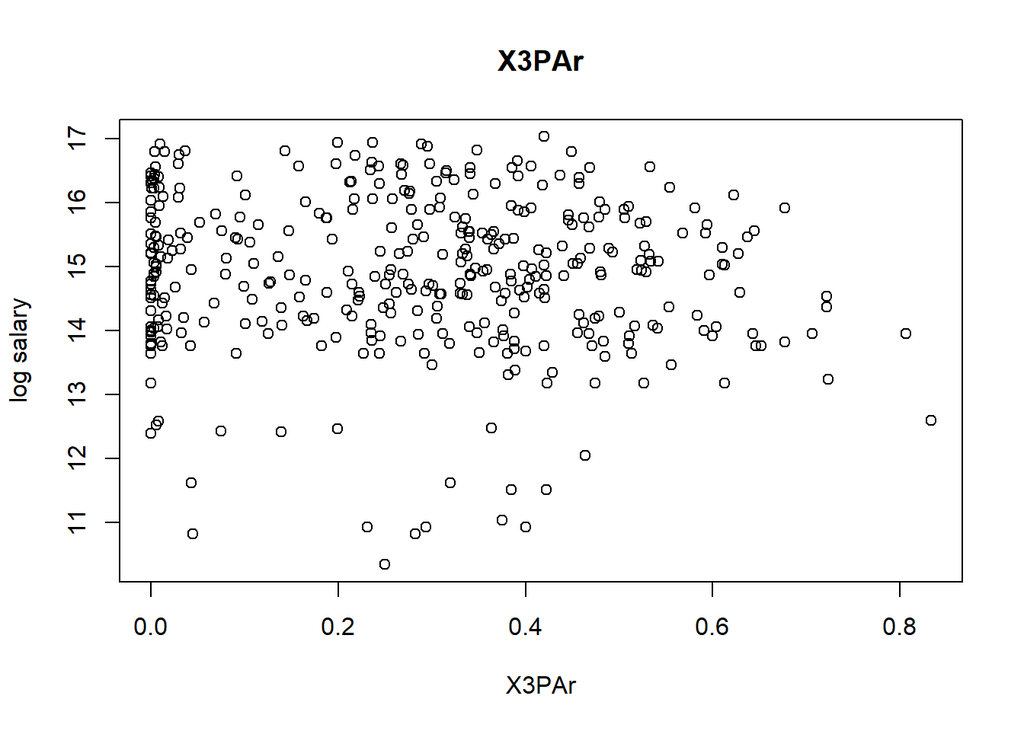

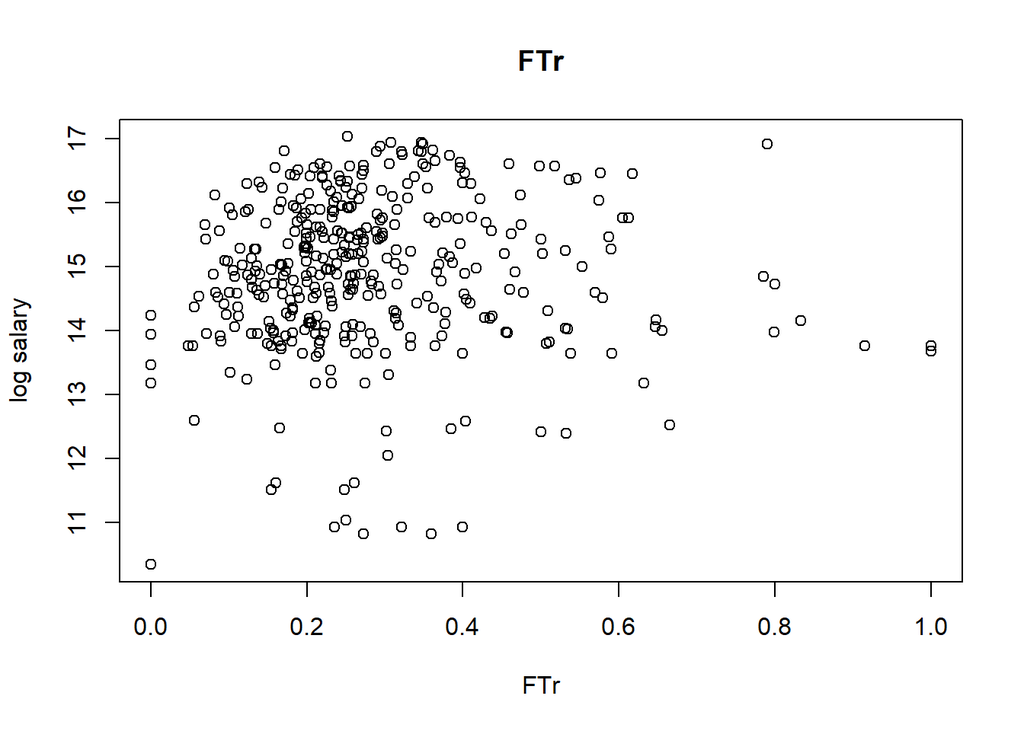

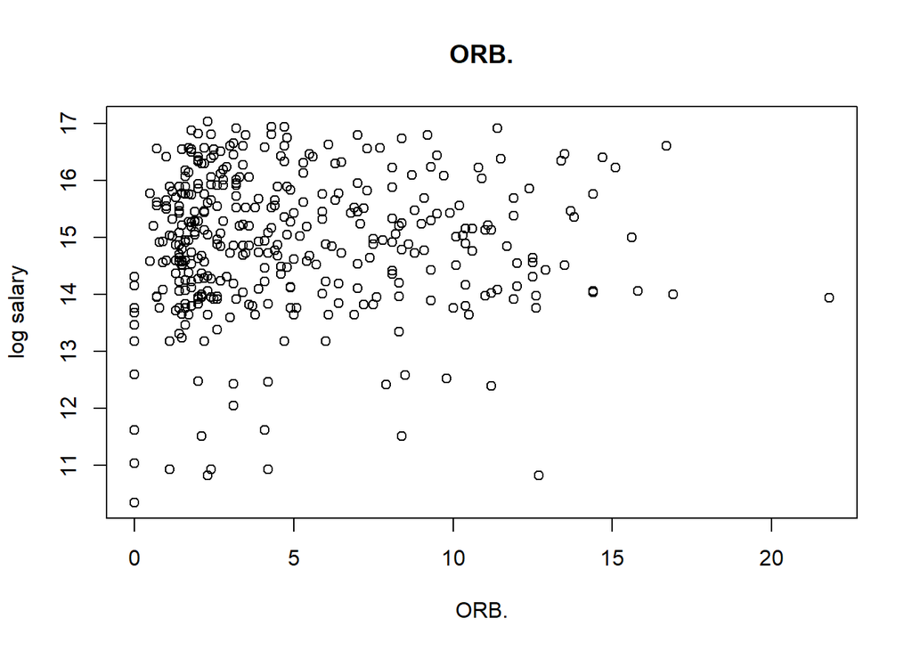

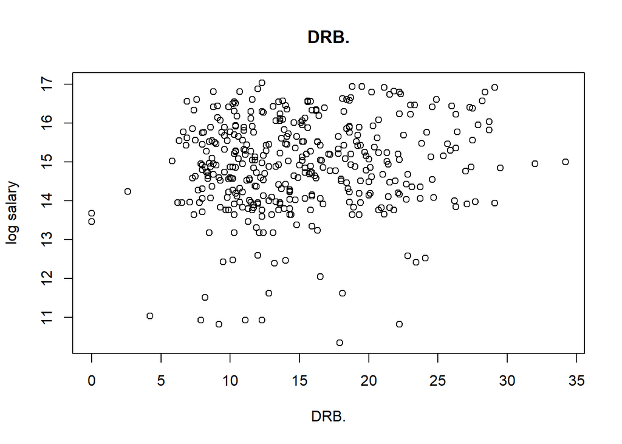

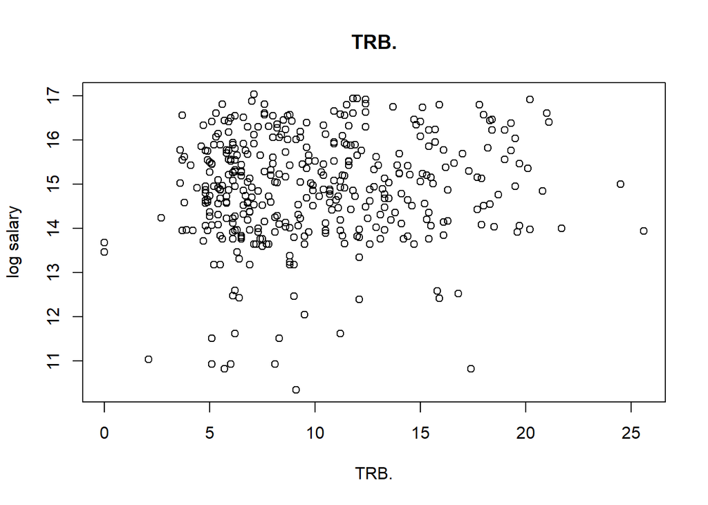

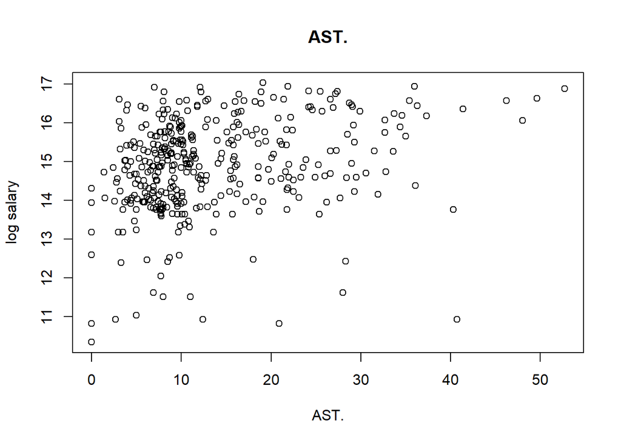

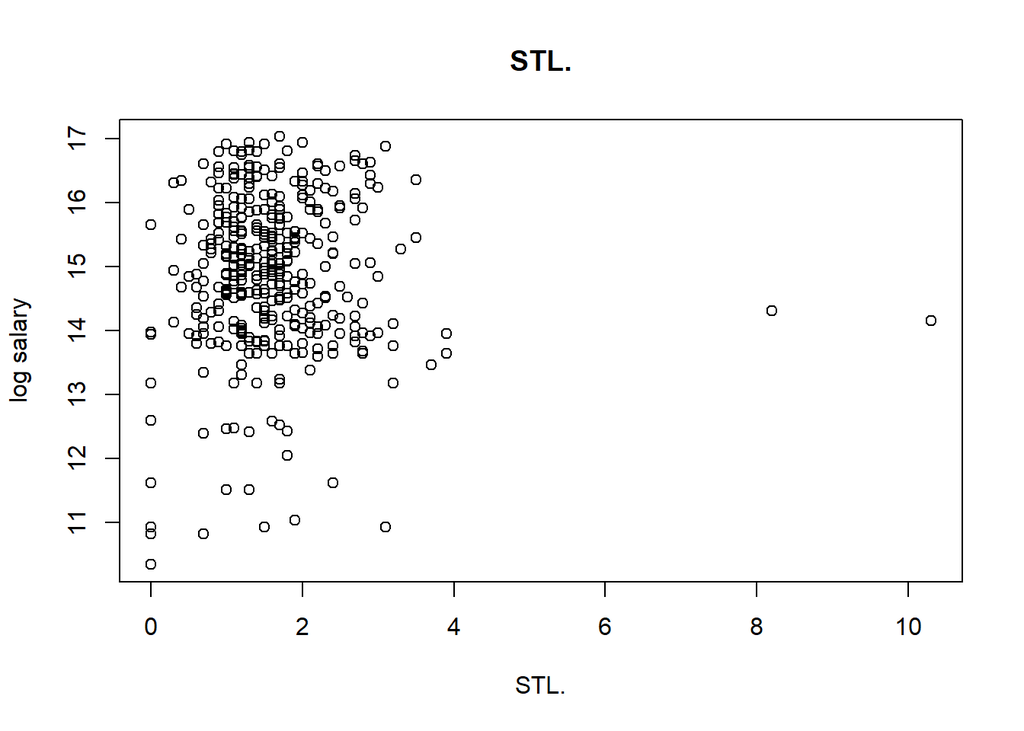

[15 more figures not shown]

```r
for (column in numeric_cols) {
    plot(player_data[, column], log(player_data$SALARY), xlab = column,
        ylab = "log salary", main = column)
}
```

We also look at the relationships between salary and each of the predictors individually. There appears to be a relationship between salary and many of the covariates individually, including simple stats such as minutes and points, as well as advanced stats like PER (Player Efficiency Rating), and Box +/-. There are many covariates that have a marginal relationship with salary. For some of them such as minutes, a marginal linear relationship seems appropriate; for others, such as VORP, a marginal linear relationship may not be appropriate. As discussed earlier, trying to transform variables and account for the multicollinearity in covariates will be some of the challenges of this project.

Some covariates, such as offensive rebounds, do not appear to have a strong marginal relationship with salary; we will investigate whether these still may affect salary through interactions with other variables.

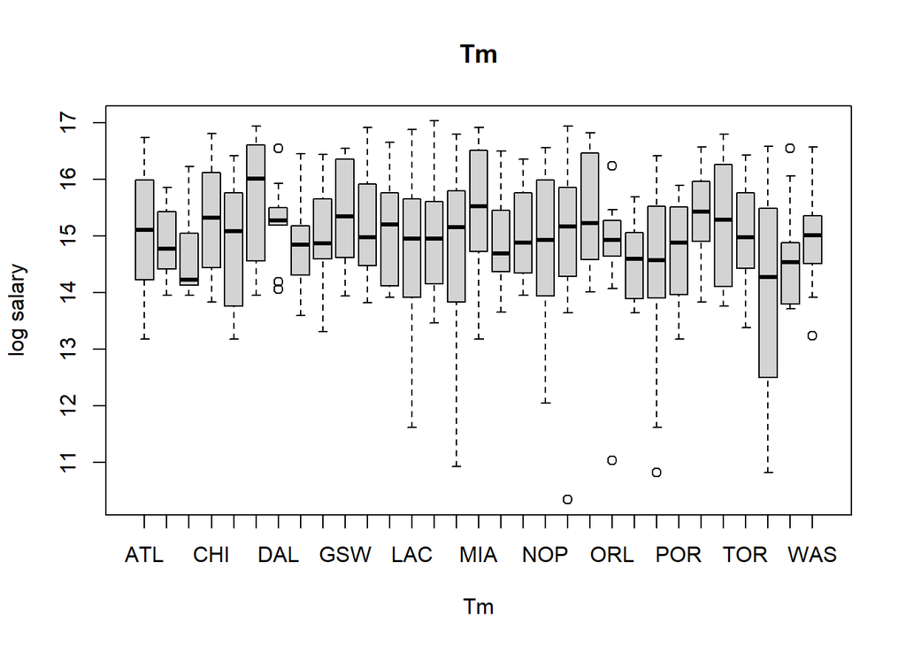

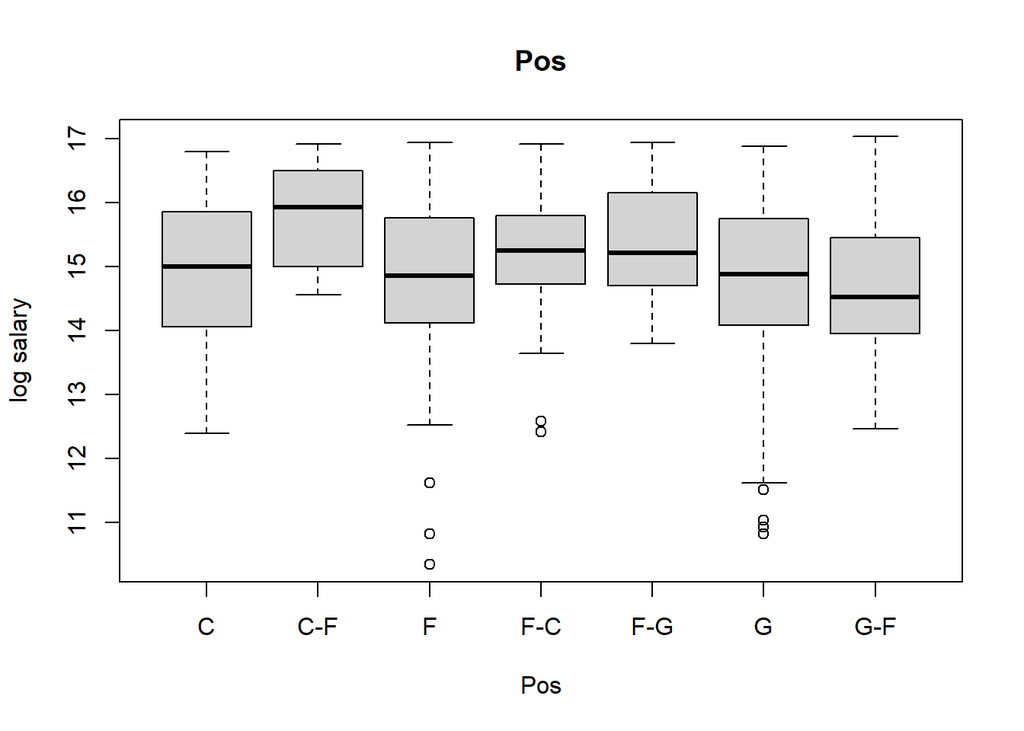

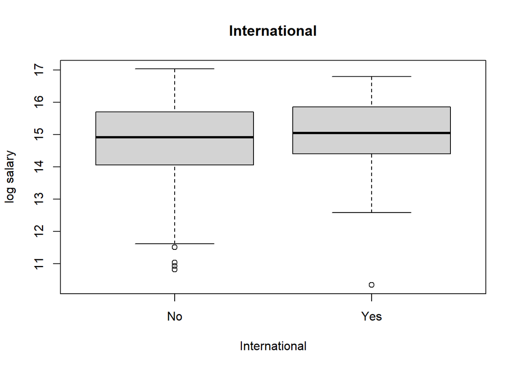

```r
for (column in categorical_cols) {
    boxplot(log(player_data$SALARY) ~ player_data[, column], xlab = column,
        ylab = "log salary", main = column)
}
```

After plotting boxplots of salary by each level of the categorical variables, salary does seem to vary across different levels of the variables. We plan to evaluate whether these relationships remain useful in the full model. Position and international each have a small number of levels; the team factor has 30 levels. We will evaluate whether this can be useful with all 30 levels, if there are ways to reduce this by grouping teams by things such as conference affiliation or market size, or if it is not useful at all in a model with less than 400 observations.

This dataset is pretty broad, which leaves us open to many possibilities for modeling approaches. As mentioned before, it seems likely we will transform the y variable in some way, possibly with a Box-Cox approach. We are certainly dealing with some multicollinearity in covariates and will need to use tools such as AVPs and VIFs to account for this. Also, interaction effects seem plausible; for example, would a change in the number of rebounds per game be associated with the same change in salary for both guards and centers? We do not initially expect any time series or any weighted linear regression.